# Risk Factor Analysis

## Outcome Variable

**Outcome Variable:** sstunted

## Predictor Variables

**Intervention Variable:** mage

**Adjustment Set:**

unadjusted

## Stratifying Variables

The analysis was stratified on these variable(s):

- agecat
- studyid
- country

## Data Summary

| agecat | studyid | country | A | n | nA | nAY0 | nAY1 |
| --- | --- | --- | --- | --- | --- | --- | --- |
| Birth | ki0047075b-MAL-ED | BANGLADESH | <20 | 257 | 36 | 35 | 1 |
| Birth | ki0047075b-MAL-ED | BANGLADESH | [20-25) | 257 | 84 | 80 | 4 |
| Birth | ki0047075b-MAL-ED | BANGLADESH | [25-30) | 257 | 92 | 90 | 2 |
| Birth | ki0047075b-MAL-ED | BANGLADESH | >=30 | 257 | 45 | 43 | 2 |
| Birth | ki0047075b-MAL-ED | BRAZIL | <20 | 191 | 34 | 33 | 1 |
| Birth | ki0047075b-MAL-ED | BRAZIL | [20-25) | 191 | 63 | 62 | 1 |
| Birth | ki0047075b-MAL-ED | BRAZIL | [25-30) | 191 | 54 | 49 | 5 |
| Birth | ki0047075b-MAL-ED | BRAZIL | >=30 | 191 | 40 | 39 | 1 |
| Birth | ki0047075b-MAL-ED | INDIA | <20 | 205 | 25 | 24 | 1 |
| Birth | ki0047075b-MAL-ED | INDIA | [20-25) | 205 | 97 | 94 | 3 |
| Birth | ki0047075b-MAL-ED | INDIA | [25-30) | 205 | 68 | 65 | 3 |
| Birth | ki0047075b-MAL-ED | INDIA | >=30 | 205 | 15 | 15 | 0 |
| Birth | ki0047075b-MAL-ED | NEPAL | <20 | 173 | 5 | 4 | 1 |
| Birth | ki0047075b-MAL-ED | NEPAL | [20-25) | 173 | 41 | 40 | 1 |
| Birth | ki0047075b-MAL-ED | NEPAL | [25-30) | 173 | 91 | 88 | 3 |
| Birth | ki0047075b-MAL-ED | NEPAL | >=30 | 173 | 36 | 35 | 1 |
| Birth | ki0047075b-MAL-ED | PERU | <20 | 287 | 77 | 73 | 4 |
| Birth | ki0047075b-MAL-ED | PERU | [20-25) | 287 | 84 | 83 | 1 |
| Birth | ki0047075b-MAL-ED | PERU | [25-30) | 287 | 61 | 59 | 2 |
| Birth | ki0047075b-MAL-ED | PERU | >=30 | 287 | 65 | 64 | 1 |
| Birth | ki0047075b-MAL-ED | SOUTH AFRICA | <20 | 262 | 41 | 40 | 1 |
| Birth | ki0047075b-MAL-ED | SOUTH AFRICA | [20-25) | 262 | 82 | 82 | 0 |
| Birth | ki0047075b-MAL-ED | SOUTH AFRICA | [25-30) | 262 | 53 | 52 | 1 |
| Birth | ki0047075b-MAL-ED | SOUTH AFRICA | >=30 | 262 | 86 | 86 | 0 |
| Birth | ki0047075b-MAL-ED | TANZANIA, UNITED REPUBLIC OF | <20 | 123 | 9 | 9 | 0 |
| Birth | ki0047075b-MAL-ED | TANZANIA, UNITED REPUBLIC OF | [20-25) | 123 | 40 | 36 | 4 |
| Birth | ki0047075b-MAL-ED | TANZANIA, UNITED REPUBLIC OF | [25-30) | 123 | 34 | 33 | 1 |
| Birth | ki0047075b-MAL-ED | TANZANIA, UNITED REPUBLIC OF | >=30 | 123 | 40 | 39 | 1 |
| Birth | ki1000108-CMC-V-BCS-2002 | INDIA | <20 | 90 | 9 | 7 | 2 |
| Birth | ki1000108-CMC-V-BCS-2002 | INDIA | [20-25) | 90 | 44 | 43 | 1 |

[output cut: 566 more lines]

The following strata were considered:

- agecat: 12 months, studyid: ki0047075b-MAL-ED, country: BANGLADESH
- agecat: 12 months, studyid: ki0047075b-MAL-ED, country: BRAZIL
- agecat: 12 months, studyid: ki0047075b-MAL-ED, country: INDIA
- agecat: 12 months, studyid: ki0047075b-MAL-ED, country: NEPAL
- agecat: 12 months, studyid: ki0047075b-MAL-ED, country: PERU
- agecat: 12 months, studyid: ki0047075b-MAL-ED, country: SOUTH AFRICA
- agecat: 12 months, studyid: ki0047075b-MAL-ED, country: TANZANIA, UNITED REPUBLIC OF
- agecat: 12 months, studyid: ki1000108-CMC-V-BCS-2002, country: INDIA
- agecat: 12 months, studyid: ki1000108-IRC, country: INDIA
- agecat: 12 months, studyid: ki1000109-EE, country: PAKISTAN
- agecat: 12 months, studyid: ki1000304b-SAS-FoodSuppl, country: INDIA
- agecat: 12 months, studyid: ki1017093-NIH-Birth, country: BANGLADESH
- agecat: 12 months, studyid: ki1017093b-PROVIDE, country: BANGLADESH
- agecat: 12 months, studyid: ki1017093c-NIH-Crypto, country: BANGLADESH
- agecat: 12 months, studyid: ki1066203-TanzaniaChild2, country: TANZANIA, UNITED REPUBLIC OF
- agecat: 12 months, studyid: ki1101329-Keneba, country: GAMBIA
- agecat: 12 months, studyid: ki1112895-Guatemala BSC, country: GUATEMALA
- agecat: 12 months, studyid: ki1113344-GMS-Nepal, country: NEPAL
- agecat: 12 months, studyid: ki1126311-ZVITAMBO, country: ZIMBABWE
- agecat: 12 months, studyid: ki1135781-COHORTS, country: GUATEMALA
- agecat: 12 months, studyid: ki1135781-COHORTS, country: INDIA
- agecat: 12 months, studyid: ki1135781-COHORTS, country: PHILIPPINES
- agecat: 12 months, studyid: ki1148112-LCNI-5, country: MALAWI
- agecat: 18 months, studyid: ki0047075b-MAL-ED, country: BANGLADESH
- agecat: 18 months, studyid: ki0047075b-MAL-ED, country: BRAZIL
- agecat: 18 months, studyid: ki0047075b-MAL-ED, country: INDIA
- agecat: 18 months, studyid: ki0047075b-MAL-ED, country: NEPAL
- agecat: 18 months, studyid: ki0047075b-MAL-ED, country: PERU
- agecat: 18 months, studyid: ki0047075b-MAL-ED, country: SOUTH AFRICA
- agecat: 18 months, studyid: ki0047075b-MAL-ED, country: TANZANIA, UNITED REPUBLIC OF
- agecat: 18 months, studyid: ki1000108-CMC-V-BCS-2002, country: INDIA
- agecat: 18 months, studyid: ki1000108-IRC, country: INDIA
- agecat: 18 months, studyid: ki1000109-EE, country: PAKISTAN
- agecat: 18 months, studyid: ki1000304b-SAS-FoodSuppl, country: INDIA
- agecat: 18 months, studyid: ki1017093-NIH-Birth, country: BANGLADESH
- agecat: 18 months, studyid: ki1017093b-PROVIDE, country: BANGLADESH
- agecat: 18 months, studyid: ki1017093c-NIH-Crypto, country: BANGLADESH
- agecat: 18 months, studyid: ki1066203-TanzaniaChild2, country: TANZANIA, UNITED REPUBLIC OF
- agecat: 18 months, studyid: ki1101329-Keneba, country: GAMBIA
- agecat: 18 months, studyid: ki1113344-GMS-Nepal, country: NEPAL
- agecat: 18 months, studyid: ki1126311-ZVITAMBO, country: ZIMBABWE
- agecat: 18 months, studyid: ki1135781-COHORTS, country: GUATEMALA
- agecat: 18 months, studyid: ki1135781-COHORTS, country: PHILIPPINES
- agecat: 18 months, studyid: ki1148112-LCNI-5, country: MALAWI
- agecat: 24 months, studyid: ki0047075b-MAL-ED, country: BANGLADESH
- agecat: 24 months, studyid: ki0047075b-MAL-ED, country: BRAZIL
- agecat: 24 months, studyid: ki0047075b-MAL-ED, country: INDIA
- agecat: 24 months, studyid: ki0047075b-MAL-ED, country: NEPAL
- agecat: 24 months, studyid: ki0047075b-MAL-ED, country: PERU
- agecat: 24 months, studyid: ki0047075b-MAL-ED, country: SOUTH AFRICA
- agecat: 24 months, studyid: ki0047075b-MAL-ED, country: TANZANIA, UNITED REPUBLIC OF
- agecat: 24 months, studyid: ki1000108-CMC-V-BCS-2002, country: INDIA
- agecat: 24 months, studyid: ki1000108-IRC, country: INDIA
- agecat: 24 months, studyid: ki1017093-NIH-Birth, country: BANGLADESH
- agecat: 24 months, studyid: ki1017093b-PROVIDE, country: BANGLADESH
- agecat: 24 months, studyid: ki1017093c-NIH-Crypto, country: BANGLADESH
- agecat: 24 months, studyid: ki1066203-TanzaniaChild2, country: TANZANIA, UNITED REPUBLIC OF
- agecat: 24 months, studyid: ki1101329-Keneba, country: GAMBIA
- agecat: 24 months, studyid: ki1113344-GMS-Nepal, country: NEPAL
- agecat: 24 months, studyid: ki1126311-ZVITAMBO, country: ZIMBABWE
- agecat: 24 months, studyid: ki1135781-COHORTS, country: GUATEMALA
- agecat: 24 months, studyid: ki1135781-COHORTS, country: INDIA
- agecat: 24 months, studyid: ki1135781-COHORTS, country: PHILIPPINES
- agecat: 24 months, studyid: ki1148112-LCNI-5, country: MALAWI
- agecat: 3 months, studyid: ki0047075b-MAL-ED, country: BANGLADESH
- agecat: 3 months, studyid: ki0047075b-MAL-ED, country: BRAZIL
- agecat: 3 months, studyid: ki0047075b-MAL-ED, country: INDIA
- agecat: 3 months, studyid: ki0047075b-MAL-ED, country: NEPAL
- agecat: 3 months, studyid: ki0047075b-MAL-ED, country: PERU
- agecat: 3 months, studyid: ki0047075b-MAL-ED, country: SOUTH AFRICA
- agecat: 3 months, studyid: ki0047075b-MAL-ED, country: TANZANIA, UNITED REPUBLIC OF
- agecat: 3 months, studyid: ki1000108-CMC-V-BCS-2002, country: INDIA
- agecat: 3 months, studyid: ki1000108-IRC, country: INDIA
- agecat: 3 months, studyid: ki1000109-EE, country: PAKISTAN
- agecat: 3 months, studyid: ki1000304b-SAS-FoodSuppl, country: INDIA
- agecat: 3 months, studyid: ki1017093-NIH-Birth, country: BANGLADESH
- agecat: 3 months, studyid: ki1017093b-PROVIDE, country: BANGLADESH
- agecat: 3 months, studyid: ki1017093c-NIH-Crypto, country: BANGLADESH
- agecat: 3 months, studyid: ki1066203-TanzaniaChild2, country: TANZANIA, UNITED REPUBLIC OF
- agecat: 3 months, studyid: ki1101329-Keneba, country: GAMBIA
- agecat: 3 months, studyid: ki1112895-Guatemala BSC, country: GUATEMALA
- agecat: 3 months, studyid: ki1113344-GMS-Nepal, country: NEPAL
- agecat: 3 months, studyid: ki1126311-ZVITAMBO, country: ZIMBABWE
- agecat: 3 months, studyid: ki1135781-COHORTS, country: GUATEMALA
- agecat: 3 months, studyid: ki1135781-COHORTS, country: INDIA
- agecat: 3 months, studyid: ki1135781-COHORTS, country: PHILIPPINES
- agecat: 6 months, studyid: ki0047075b-MAL-ED, country: BANGLADESH
- agecat: 6 months, studyid: ki0047075b-MAL-ED, country: BRAZIL
- agecat: 6 months, studyid: ki0047075b-MAL-ED, country: INDIA
- agecat: 6 months, studyid: ki0047075b-MAL-ED, country: NEPAL
- agecat: 6 months, studyid: ki0047075b-MAL-ED, country: PERU
- agecat: 6 months, studyid: ki0047075b-MAL-ED, country: SOUTH AFRICA
- agecat: 6 months, studyid: ki0047075b-MAL-ED, country: TANZANIA, UNITED REPUBLIC OF
- agecat: 6 months, studyid: ki1000108-CMC-V-BCS-2002, country: INDIA
- agecat: 6 months, studyid: ki1000108-IRC, country: INDIA
- agecat: 6 months, studyid: ki1000109-EE, country: PAKISTAN
- agecat: 6 months, studyid: ki1000304b-SAS-FoodSuppl, country: INDIA
- agecat: 6 months, studyid: ki1017093-NIH-Birth, country: BANGLADESH
- agecat: 6 months, studyid: ki1017093b-PROVIDE, country: BANGLADESH
- agecat: 6 months, studyid: ki1017093c-NIH-Crypto, country: BANGLADESH
- agecat: 6 months, studyid: ki1066203-TanzaniaChild2, country: TANZANIA, UNITED REPUBLIC OF
- agecat: 6 months, studyid: ki1101329-Keneba, country: GAMBIA
- agecat: 6 months, studyid: ki1112895-Guatemala BSC, country: GUATEMALA
- agecat: 6 months, studyid: ki1113344-GMS-Nepal, country: NEPAL
- agecat: 6 months, studyid: ki1126311-ZVITAMBO, country: ZIMBABWE
- agecat: 6 months, studyid: ki1135781-COHORTS, country: GUATEMALA
- agecat: 6 months, studyid: ki1135781-COHORTS, country: INDIA
- agecat: 6 months, studyid: ki1135781-COHORTS, country: PHILIPPINES
- agecat: 6 months, studyid: ki1148112-LCNI-5, country: MALAWI
- agecat: 9 months, studyid: ki0047075b-MAL-ED, country: BANGLADESH
- agecat: 9 months, studyid: ki0047075b-MAL-ED, country: BRAZIL
- agecat: 9 months, studyid: ki0047075b-MAL-ED, country: INDIA
- agecat: 9 months, studyid: ki0047075b-MAL-ED, country: NEPAL
- agecat: 9 months, studyid: ki0047075b-MAL-ED, country: PERU
- agecat: 9 months, studyid: ki0047075b-MAL-ED, country: SOUTH AFRICA
- agecat: 9 months, studyid: ki0047075b-MAL-ED, country: TANZANIA, UNITED REPUBLIC OF
- agecat: 9 months, studyid: ki1000108-CMC-V-BCS-2002, country: INDIA
- agecat: 9 months, studyid: ki1000108-IRC, country: INDIA
- agecat: 9 months, studyid: ki1000109-EE, country: PAKISTAN
- agecat: 9 months, studyid: ki1000304b-SAS-FoodSuppl, country: INDIA
- agecat: 9 months, studyid: ki1017093-NIH-Birth, country: BANGLADESH
- agecat: 9 months, studyid: ki1017093b-PROVIDE, country: BANGLADESH
- agecat: 9 months, studyid: ki1017093c-NIH-Crypto, country: BANGLADESH
- agecat: 9 months, studyid: ki1066203-TanzaniaChild2, country: TANZANIA, UNITED REPUBLIC OF
- agecat: 9 months, studyid: ki1101329-Keneba, country: GAMBIA
- agecat: 9 months, studyid: ki1112895-Guatemala BSC, country: GUATEMALA
- agecat: 9 months, studyid: ki1113344-GMS-Nepal, country: NEPAL
- agecat: 9 months, studyid: ki1126311-ZVITAMBO, country: ZIMBABWE
- agecat: 9 months, studyid: ki1135781-COHORTS, country: GUATEMALA
- agecat: 9 months, studyid: ki1135781-COHORTS, country: INDIA
- agecat: 9 months, studyid: ki1135781-COHORTS, country: PHILIPPINES
- agecat: 9 months, studyid: ki1148112-LCNI-5, country: MALAWI
- agecat: Birth, studyid: ki0047075b-MAL-ED, country: BANGLADESH
- agecat: Birth, studyid: ki0047075b-MAL-ED, country: BRAZIL
- agecat: Birth, studyid: ki0047075b-MAL-ED, country: INDIA
- agecat: Birth, studyid: ki0047075b-MAL-ED, country: NEPAL
- agecat: Birth, studyid: ki0047075b-MAL-ED, country: PERU
- agecat: Birth, studyid: ki0047075b-MAL-ED, country: SOUTH AFRICA
- agecat: Birth, studyid: ki0047075b-MAL-ED, country: TANZANIA, UNITED REPUBLIC OF
- agecat: Birth, studyid: ki1000108-CMC-V-BCS-2002, country: INDIA
- agecat: Birth, studyid: ki1000108-IRC, country: INDIA
- agecat: Birth, studyid: ki1000109-EE, country: PAKISTAN
- agecat: Birth, studyid: ki1017093-NIH-Birth, country: BANGLADESH
- agecat: Birth, studyid: ki1017093c-NIH-Crypto, country: BANGLADESH
- agecat: Birth, studyid: ki1101329-Keneba, country: GAMBIA
- agecat: Birth, studyid: ki1126311-ZVITAMBO, country: ZIMBABWE
- agecat: Birth, studyid: ki1135781-COHORTS, country: GUATEMALA
- agecat: Birth, studyid: ki1135781-COHORTS, country: INDIA
- agecat: Birth, studyid: ki1135781-COHORTS, country: PHILIPPINES

### Dropped Strata

Some strata were dropped due to rare outcomes:

- agecat: Birth, studyid: ki0047075b-MAL-ED, country: BANGLADESH
- agecat: Birth, studyid: ki0047075b-MAL-ED, country: BRAZIL
- agecat: Birth, studyid: ki0047075b-MAL-ED, country: INDIA
- agecat: Birth, studyid: ki0047075b-MAL-ED, country: NEPAL
- agecat: Birth, studyid: ki0047075b-MAL-ED, country: PERU
- agecat: Birth, studyid: ki0047075b-MAL-ED, country: SOUTH AFRICA
- agecat: Birth, studyid: ki0047075b-MAL-ED, country: TANZANIA, UNITED REPUBLIC OF
- agecat: Birth, studyid: ki1000108-CMC-V-BCS-2002, country: INDIA
- agecat: Birth, studyid: ki1000108-IRC, country: INDIA
- agecat: Birth, studyid: ki1000109-EE, country: PAKISTAN
- agecat: Birth, studyid: ki1017093-NIH-Birth, country: BANGLADESH
- agecat: Birth, studyid: ki1017093c-NIH-Crypto, country: BANGLADESH
- agecat: Birth, studyid: ki1101329-Keneba, country: GAMBIA
- agecat: Birth, studyid: ki1135781-COHORTS, country: GUATEMALA
- agecat: 3 months, studyid: ki0047075b-MAL-ED, country: BANGLADESH
- agecat: 3 months, studyid: ki0047075b-MAL-ED, country: BRAZIL
- agecat: 3 months, studyid: ki0047075b-MAL-ED, country: INDIA
- agecat: 3 months, studyid: ki0047075b-MAL-ED, country: NEPAL
- agecat: 3 months, studyid: ki0047075b-MAL-ED, country: PERU
- agecat: 3 months, studyid: ki0047075b-MAL-ED, country: SOUTH AFRICA
- agecat: 3 months, studyid: ki0047075b-MAL-ED, country: TANZANIA, UNITED REPUBLIC OF
- agecat: 3 months, studyid: ki1000108-CMC-V-BCS-2002, country: INDIA
- agecat: 3 months, studyid: ki1000108-IRC, country: INDIA
- agecat: 3 months, studyid: ki1000109-EE, country: PAKISTAN
- agecat: 3 months, studyid: ki1000304b-SAS-FoodSuppl, country: INDIA
- agecat: 3 months, studyid: ki1017093-NIH-Birth, country: BANGLADESH
- agecat: 3 months, studyid: ki1017093b-PROVIDE, country: BANGLADESH
- agecat: 3 months, studyid: ki1017093c-NIH-Crypto, country: BANGLADESH
- agecat: 3 months, studyid: ki1066203-TanzaniaChild2, country: TANZANIA, UNITED REPUBLIC OF
- agecat: 3 months, studyid: ki1112895-Guatemala BSC, country: GUATEMALA
- agecat: 3 months, studyid: ki1113344-GMS-Nepal, country: NEPAL
- agecat: 6 months, studyid: ki0047075b-MAL-ED, country: BANGLADESH
- agecat: 6 months, studyid: ki0047075b-MAL-ED, country: BRAZIL
- agecat: 6 months, studyid: ki0047075b-MAL-ED, country: INDIA
- agecat: 6 months, studyid: ki0047075b-MAL-ED, country: NEPAL
- agecat: 6 months, studyid: ki0047075b-MAL-ED, country: PERU
- agecat: 6 months, studyid: ki0047075b-MAL-ED, country: SOUTH AFRICA
- agecat: 6 months, studyid: ki0047075b-MAL-ED, country: TANZANIA, UNITED REPUBLIC OF
- agecat: 6 months, studyid: ki1000108-CMC-V-BCS-2002, country: INDIA
- agecat: 6 months, studyid: ki1000108-IRC, country: INDIA
- agecat: 6 months, studyid: ki1000109-EE, country: PAKISTAN
- agecat: 6 months, studyid: ki1000304b-SAS-FoodSuppl, country: INDIA
- agecat: 6 months, studyid: ki1017093-NIH-Birth, country: BANGLADESH
- agecat: 6 months, studyid: ki1017093b-PROVIDE, country: BANGLADESH
- agecat: 6 months, studyid: ki1066203-TanzaniaChild2, country: TANZANIA, UNITED REPUBLIC OF
- agecat: 6 months, studyid: ki1101329-Keneba, country: GAMBIA
- agecat: 6 months, studyid: ki1112895-Guatemala BSC, country: GUATEMALA
- agecat: 6 months, studyid: ki1113344-GMS-Nepal, country: NEPAL
- agecat: 6 months, studyid: ki1135781-COHORTS, country: GUATEMALA
- agecat: 6 months, studyid: ki1148112-LCNI-5, country: MALAWI
- agecat: 9 months, studyid: ki0047075b-MAL-ED, country: BANGLADESH
- agecat: 9 months, studyid: ki0047075b-MAL-ED, country: BRAZIL
- agecat: 9 months, studyid: ki0047075b-MAL-ED, country: INDIA
- agecat: 9 months, studyid: ki0047075b-MAL-ED, country: NEPAL
- agecat: 9 months, studyid: ki0047075b-MAL-ED, country: PERU
- agecat: 9 months, studyid: ki0047075b-MAL-ED, country: SOUTH AFRICA
- agecat: 9 months, studyid: ki0047075b-MAL-ED, country: TANZANIA, UNITED REPUBLIC OF
- agecat: 9 months, studyid: ki1000108-CMC-V-BCS-2002, country: INDIA
- agecat: 9 months, studyid: ki1000108-IRC, country: INDIA
- agecat: 9 months, studyid: ki1000109-EE, country: PAKISTAN
- agecat: 9 months, studyid: ki1000304b-SAS-FoodSuppl, country: INDIA
- agecat: 9 months, studyid: ki1017093-NIH-Birth, country: BANGLADESH
- agecat: 9 months, studyid: ki1017093b-PROVIDE, country: BANGLADESH
- agecat: 9 months, studyid: ki1066203-TanzaniaChild2, country: TANZANIA, UNITED REPUBLIC OF
- agecat: 9 months, studyid: ki1148112-LCNI-5, country: MALAWI
- agecat: 12 months, studyid: ki0047075b-MAL-ED, country: BANGLADESH
- agecat: 12 months, studyid: ki0047075b-MAL-ED, country: BRAZIL
- agecat: 12 months, studyid: ki0047075b-MAL-ED, country: INDIA
- agecat: 12 months, studyid: ki0047075b-MAL-ED, country: NEPAL
- agecat: 12 months, studyid: ki0047075b-MAL-ED, country: PERU
- agecat: 12 months, studyid: ki0047075b-MAL-ED, country: SOUTH AFRICA
- agecat: 12 months, studyid: ki0047075b-MAL-ED, country: TANZANIA, UNITED REPUBLIC OF
- agecat: 12 months, studyid: ki1000108-IRC, country: INDIA
- agecat: 12 months, studyid: ki1000109-EE, country: PAKISTAN
- agecat: 12 months, studyid: ki1000304b-SAS-FoodSuppl, country: INDIA
- agecat: 12 months, studyid: ki1017093-NIH-Birth, country: BANGLADESH
- agecat: 12 months, studyid: ki1017093b-PROVIDE, country: BANGLADESH
- agecat: 12 months, studyid: ki1066203-TanzaniaChild2, country: TANZANIA, UNITED REPUBLIC OF
- agecat: 12 months, studyid: ki1148112-LCNI-5, country: MALAWI
- agecat: 18 months, studyid: ki0047075b-MAL-ED, country: BANGLADESH
- agecat: 18 months, studyid: ki0047075b-MAL-ED, country: BRAZIL
- agecat: 18 months, studyid: ki0047075b-MAL-ED, country: INDIA
- agecat: 18 months, studyid: ki0047075b-MAL-ED, country: NEPAL
- agecat: 18 months, studyid: ki0047075b-MAL-ED, country: PERU
- agecat: 18 months, studyid: ki0047075b-MAL-ED, country: SOUTH AFRICA
- agecat: 18 months, studyid: ki0047075b-MAL-ED, country: TANZANIA, UNITED REPUBLIC OF
- agecat: 18 months, studyid: ki1000108-IRC, country: INDIA
- agecat: 18 months, studyid: ki1000109-EE, country: PAKISTAN
- agecat: 18 months, studyid: ki1000304b-SAS-FoodSuppl, country: INDIA
- agecat: 18 months, studyid: ki1017093c-NIH-Crypto, country: BANGLADESH
- agecat: 18 months, studyid: ki1066203-TanzaniaChild2, country: TANZANIA, UNITED REPUBLIC OF
- agecat: 24 months, studyid: ki0047075b-MAL-ED, country: BRAZIL
- agecat: 24 months, studyid: ki0047075b-MAL-ED, country: INDIA
- agecat: 24 months, studyid: ki0047075b-MAL-ED, country: NEPAL
- agecat: 24 months, studyid: ki0047075b-MAL-ED, country: PERU
- agecat: 24 months, studyid: ki0047075b-MAL-ED, country: SOUTH AFRICA
- agecat: 24 months, studyid: ki0047075b-MAL-ED, country: TANZANIA, UNITED REPUBLIC OF
- agecat: 24 months, studyid: ki1000108-IRC, country: INDIA
- agecat: 24 months, studyid: ki1017093-NIH-Birth, country: BANGLADESH
- agecat: 24 months, studyid: ki1017093c-NIH-Crypto, country: BANGLADESH
- agecat: 24 months, studyid: ki1066203-TanzaniaChild2, country: TANZANIA, UNITED REPUBLIC OF

## Methods Detail

We’re interested in the causal parameters $E[Y_a]$ for all values of $a \in \mathcal{A}$. These parameters represent the mean outcome if, possibly contrary to fact, we intervened to set all units to have $A=a$. Under the randomization and positivity assumptions, these are identified by the statistical parameters $\psi_a=E_W[E_{Y|A,W}(Y|A=a,W)]$. In addition, we’re interested in the mean of $Y$, $E[Y]$ under no intervention (the observed mean). We will estimate these parameters by using SuperLearner to fit the relevant likelihood factors – $E_{Y|A,W}(Y|A=a,W)$ and $p(A=a|W)$, and then updating our likelihood fit using a joint TMLE.

For unadjusted analyses ($W=\{\}$), initial likelihoods were estimated using Lrnr_glm to estimate the simple $E(Y|A)$ and Lrnr_mean to estimate $p(A)$. For adjusted analyses, a small library containing Lrnr_glmnet, Lrnr_xgboost, and Lrnr_mean was used.

Having estimated these parameters, we will then use the delta method to estimate relative risks and attributable risks relative to a prespecified baseline level of $A$.

# Results Detail

## Results Plots

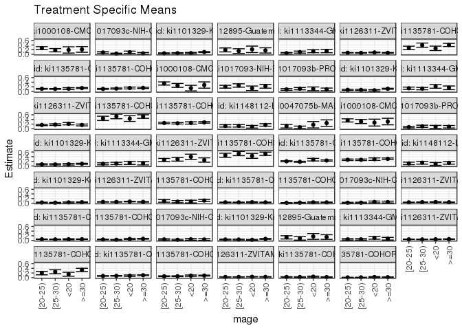

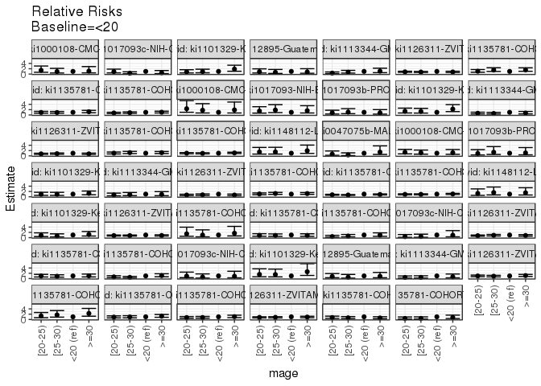

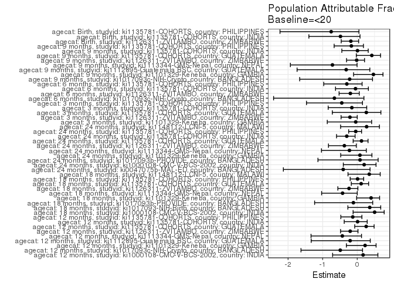

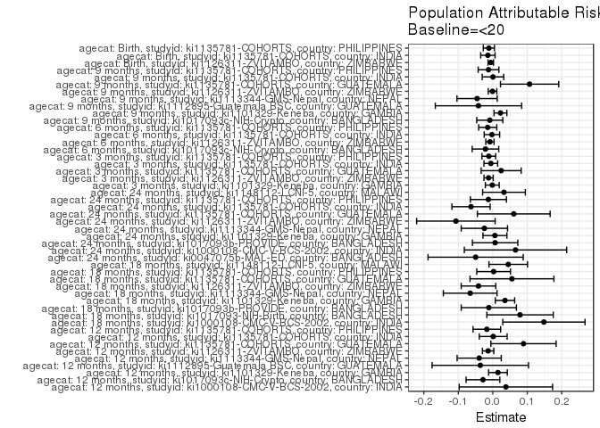

## Results Table

### Parameter: TSM

| agecat | studyid | country | intervention_level | baseline_level | estimate | ci_lower | ci_upper |
| --- | --- | --- | --- | --- | --- | --- | --- |
| Birth | ki1126311-ZVITAMBO | ZIMBABWE | <20 | NA | 0.0377273 | 0.0297651 | 0.0456894 |
| Birth | ki1126311-ZVITAMBO | ZIMBABWE | [20-25) | NA | 0.0297047 | 0.0253444 | 0.0340650 |
| Birth | ki1126311-ZVITAMBO | ZIMBABWE | [25-30) | NA | 0.0302150 | 0.0244962 | 0.0359338 |
| Birth | ki1126311-ZVITAMBO | ZIMBABWE | >=30 | NA | 0.0339931 | 0.0266254 | 0.0413608 |
| Birth | ki1135781-COHORTS | INDIA | <20 | NA | 0.0434783 | 0.0226404 | 0.0643162 |
| Birth | ki1135781-COHORTS | INDIA | [20-25) | NA | 0.0314427 | 0.0229491 | 0.0399362 |
| Birth | ki1135781-COHORTS | INDIA | [25-30) | NA | 0.0269576 | 0.0189147 | 0.0350006 |
| Birth | ki1135781-COHORTS | INDIA | >=30 | NA | 0.0248500 | 0.0159179 | 0.0337822 |
| Birth | ki1135781-COHORTS | PHILIPPINES | <20 | NA | 0.0264550 | 0.0102740 | 0.0426360 |
| Birth | ki1135781-COHORTS | PHILIPPINES | [20-25) | NA | 0.0103520 | 0.0039681 | 0.0167358 |
| Birth | ki1135781-COHORTS | PHILIPPINES | [25-30) | NA | 0.0105263 | 0.0036844 | 0.0173682 |
| Birth | ki1135781-COHORTS | PHILIPPINES | >=30 | NA | 0.0199765 | 0.0105742 | 0.0293788 |
| 3 months | ki1101329-Keneba | GAMBIA | <20 | NA | 0.0345912 | 0.0145015 | 0.0546809 |
| 3 months | ki1101329-Keneba | GAMBIA | [20-25) | NA | 0.0298246 | 0.0158569 | 0.0437922 |
| 3 months | ki1101329-Keneba | GAMBIA | [25-30) | NA | 0.0214133 | 0.0082813 | 0.0345453 |
| 3 months | ki1101329-Keneba | GAMBIA | >=30 | NA | 0.0415140 | 0.0278495 | 0.0551786 |
| 3 months | ki1126311-ZVITAMBO | ZIMBABWE | <20 | NA | 0.0694842 | 0.0561449 | 0.0828236 |
| 3 months | ki1126311-ZVITAMBO | ZIMBABWE | [20-25) | NA | 0.0550040 | 0.0476841 | 0.0623239 |
| 3 months | ki1126311-ZVITAMBO | ZIMBABWE | [25-30) | NA | 0.0539507 | 0.0448238 | 0.0630776 |
| 3 months | ki1126311-ZVITAMBO | ZIMBABWE | >=30 | NA | 0.0571934 | 0.0461413 | 0.0682455 |
| 3 months | ki1135781-COHORTS | GUATEMALA | <20 | NA | 0.0684932 | 0.0104886 | 0.1264977 |
| 3 months | ki1135781-COHORTS | GUATEMALA | [20-25) | NA | 0.0982143 | 0.0430400 | 0.1533886 |
| 3 months | ki1135781-COHORTS | GUATEMALA | [25-30) | NA | 0.0666667 | 0.0189044 | 0.1144289 |
| 3 months | ki1135781-COHORTS | GUATEMALA | >=30 | NA | 0.1141304 | 0.0681383 | 0.1601226 |
| 3 months | ki1135781-COHORTS | INDIA | <20 | NA | 0.0426065 | 0.0227872 | 0.0624258 |
| 3 months | ki1135781-COHORTS | INDIA | [20-25) | NA | 0.0374856 | 0.0285442 | 0.0464269 |
| 3 months | ki1135781-COHORTS | INDIA | [25-30) | NA | 0.0354354 | 0.0265543 | 0.0443166 |
| 3 months | ki1135781-COHORTS | INDIA | >=30 | NA | 0.0359771 | 0.0255387 | 0.0464155 |
| 3 months | ki1135781-COHORTS | PHILIPPINES | <20 | NA | 0.0372493 | 0.0173780 | 0.0571206 |
| 3 months | ki1135781-COHORTS | PHILIPPINES | [20-25) | NA | 0.0155039 | 0.0074444 | 0.0235634 |

[output cut: 162 more lines]

### Parameter: E(Y)

| agecat | studyid | country | intervention_level | baseline_level | estimate | ci_lower | ci_upper |
| --- | --- | --- | --- | --- | --- | --- | --- |
| Birth | ki1126311-ZVITAMBO | ZIMBABWE | NA | NA | 0.0318347 | 0.0317849 | 0.0318844 |
| Birth | ki1135781-COHORTS | INDIA | NA | NA | 0.0292683 | 0.0291285 | 0.0294081 |
| Birth | ki1135781-COHORTS | PHILIPPINES | NA | NA | 0.0150820 | 0.0148701 | 0.0152938 |
| 3 months | ki1101329-Keneba | GAMBIA | NA | NA | 0.0331187 | 0.0327953 | 0.0334420 |
| 3 months | ki1126311-ZVITAMBO | ZIMBABWE | NA | NA | 0.0573422 | 0.0572347 | 0.0574497 |
| 3 months | ki1135781-COHORTS | GUATEMALA | NA | NA | 0.0928270 | 0.0909673 | 0.0946867 |
| 3 months | ki1135781-COHORTS | INDIA | NA | NA | 0.0368452 | 0.0367926 | 0.0368979 |
| 3 months | ki1135781-COHORTS | PHILIPPINES | NA | NA | 0.0257391 | 0.0254125 | 0.0260658 |
| 6 months | ki1017093c-NIH-Crypto | BANGLADESH | NA | NA | 0.0321678 | 0.0311186 | 0.0332171 |
| 6 months | ki1126311-ZVITAMBO | ZIMBABWE | NA | NA | 0.0416667 | 0.0415686 | 0.0417648 |
| 6 months | ki1135781-COHORTS | INDIA | NA | NA | 0.0487357 | 0.0486451 | 0.0488263 |
| 6 months | ki1135781-COHORTS | PHILIPPINES | NA | NA | 0.0487445 | 0.0480945 | 0.0493944 |
| 9 months | ki1017093c-NIH-Crypto | BANGLADESH | NA | NA | 0.0396601 | 0.0390675 | 0.0402526 |
| 9 months | ki1101329-Keneba | GAMBIA | NA | NA | 0.0476422 | 0.0469928 | 0.0482916 |
| 9 months | ki1112895-Guatemala BSC | GUATEMALA | NA | NA | 0.1298701 | 0.1263200 | 0.1334203 |
| 9 months | ki1113344-GMS-Nepal | NEPAL | NA | NA | 0.0635209 | 0.0614756 | 0.0655661 |
| 9 months | ki1126311-ZVITAMBO | ZIMBABWE | NA | NA | 0.0481912 | 0.0481047 | 0.0482777 |
| 9 months | ki1135781-COHORTS | GUATEMALA | NA | NA | 0.2538631 | 0.2473095 | 0.2604168 |
| 9 months | ki1135781-COHORTS | INDIA | NA | NA | 0.0835863 | 0.0832359 | 0.0839366 |
| 9 months | ki1135781-COHORTS | PHILIPPINES | NA | NA | 0.0722714 | 0.0717819 | 0.0727608 |
| 12 months | ki1000108-CMC-V-BCS-2002 | INDIA | NA | NA | 0.2255435 | 0.2213795 | 0.2297074 |
| 12 months | ki1017093c-NIH-Crypto | BANGLADESH | NA | NA | 0.0580737 | 0.0562149 | 0.0599324 |
| 12 months | ki1101329-Keneba | GAMBIA | NA | NA | 0.0661499 | 0.0650547 | 0.0672450 |
| 12 months | ki1112895-Guatemala BSC | GUATEMALA | NA | NA | 0.1758794 | 0.1723687 | 0.1793901 |
| 12 months | ki1113344-GMS-Nepal | NEPAL | NA | NA | 0.0913978 | 0.0883119 | 0.0944838 |
| 12 months | ki1126311-ZVITAMBO | ZIMBABWE | NA | NA | 0.0659635 | 0.0658188 | 0.0661081 |
| 12 months | ki1135781-COHORTS | GUATEMALA | NA | NA | 0.3452158 | 0.3397001 | 0.3507314 |
| 12 months | ki1135781-COHORTS | INDIA | NA | NA | 0.1237248 | 0.1232517 | 0.1241980 |
| 12 months | ki1135781-COHORTS | PHILIPPINES | NA | NA | 0.1330754 | 0.1323647 | 0.1337862 |
| 18 months | ki1000108-CMC-V-BCS-2002 | INDIA | NA | NA | 0.2953930 | 0.2892041 | 0.3015818 |
| 18 months | ki1017093-NIH-Birth | BANGLADESH | NA | NA | 0.2190889 | 0.2158815 | 0.2222964 |
| 18 months | ki1017093b-PROVIDE | BANGLADESH | NA | NA | 0.1032609 | 0.1020415 | 0.1044803 |
| 18 months | ki1101329-Keneba | GAMBIA | NA | NA | 0.0884817 | 0.0873428 | 0.0896205 |
| 18 months | ki1113344-GMS-Nepal | NEPAL | NA | NA | 0.1545455 | 0.1516773 | 0.1574136 |
| 18 months | ki1126311-ZVITAMBO | ZIMBABWE | NA | NA | 0.1746776 | 0.1737854 | 0.1755698 |
| 18 months | ki1135781-COHORTS | GUATEMALA | NA | NA | 0.4931193 | 0.4892337 | 0.4970048 |
| 18 months | ki1135781-COHORTS | PHILIPPINES | NA | NA | 0.2516051 | 0.2510140 | 0.2521962 |
| 18 months | ki1148112-LCNI-5 | MALAWI | NA | NA | 0.1290323 | 0.1269117 | 0.1311528 |
| 24 months | ki0047075b-MAL-ED | BANGLADESH | NA | NA | 0.1226415 | 0.1136899 | 0.1315931 |
| 24 months | ki1000108-CMC-V-BCS-2002 | INDIA | NA | NA | 0.3306452 | 0.3275344 | 0.3337559 |
| 24 months | ki1017093b-PROVIDE | BANGLADESH | NA | NA | 0.0849220 | 0.0836704 | 0.0861737 |
| 24 months | ki1101329-Keneba | GAMBIA | NA | NA | 0.0799300 | 0.0793355 | 0.0805245 |
| 24 months | ki1113344-GMS-Nepal | NEPAL | NA | NA | 0.1082164 | 0.1069205 | 0.1095124 |
| 24 months | ki1126311-ZVITAMBO | ZIMBABWE | NA | NA | 0.2872807 | 0.2828989 | 0.2916625 |
| 24 months | ki1135781-COHORTS | GUATEMALA | NA | NA | 0.4961390 | 0.4927698 | 0.4995082 |
| 24 months | ki1135781-COHORTS | INDIA | NA | NA | 0.2081191 | 0.2072606 | 0.2089775 |
| 24 months | ki1135781-COHORTS | PHILIPPINES | NA | NA | 0.2817996 | 0.2810758 | 0.2825234 |
| 24 months | ki1148112-LCNI-5 | MALAWI | NA | NA | 0.1200000 | 0.1183362 | 0.1216639 |

### Parameter: RR

| agecat | studyid | country | intervention_level | baseline_level | estimate | ci_lower | ci_upper |
| --- | --- | --- | --- | --- | --- | --- | --- |
| Birth | ki1126311-ZVITAMBO | ZIMBABWE | <20 | <20 | 1.0000000 | 1.0000000 | 1.0000000 |
| Birth | ki1126311-ZVITAMBO | ZIMBABWE | [20-25) | <20 | 0.7873527 | 0.6088689 | 1.0181572 |
| Birth | ki1126311-ZVITAMBO | ZIMBABWE | [25-30) | <20 | 0.8008793 | 0.6031861 | 1.0633660 |
| Birth | ki1126311-ZVITAMBO | ZIMBABWE | >=30 | <20 | 0.9010223 | 0.6658161 | 1.2193176 |
| Birth | ki1135781-COHORTS | INDIA | <20 | <20 | 1.0000000 | 1.0000000 | 1.0000000 |
| Birth | ki1135781-COHORTS | INDIA | [20-25) | <20 | 0.7231813 | 0.4171744 | 1.2536509 |
| Birth | ki1135781-COHORTS | INDIA | [25-30) | <20 | 0.6200257 | 0.3525562 | 1.0904130 |
| Birth | ki1135781-COHORTS | INDIA | >=30 | <20 | 0.5715510 | 0.3139615 | 1.0404796 |
| Birth | ki1135781-COHORTS | PHILIPPINES | <20 | <20 | 1.0000000 | 1.0000000 | 1.0000000 |
| Birth | ki1135781-COHORTS | PHILIPPINES | [20-25) | <20 | 0.3913043 | 0.1641735 | 0.9326664 |
| Birth | ki1135781-COHORTS | PHILIPPINES | [25-30) | <20 | 0.3978947 | 0.1629876 | 0.9713637 |
| Birth | ki1135781-COHORTS | PHILIPPINES | >=30 | <20 | 0.7551116 | 0.3490074 | 1.6337578 |
| 3 months | ki1101329-Keneba | GAMBIA | <20 | <20 | 1.0000000 | 1.0000000 | 1.0000000 |
| 3 months | ki1101329-Keneba | GAMBIA | [20-25) | <20 | 0.8622010 | 0.4088765 | 1.8181297 |
| 3 months | ki1101329-Keneba | GAMBIA | [25-30) | <20 | 0.6190384 | 0.2660122 | 1.4405675 |
| 3 months | ki1101329-Keneba | GAMBIA | >=30 | <20 | 1.2001332 | 0.6156161 | 2.3396395 |
| 3 months | ki1126311-ZVITAMBO | ZIMBABWE | <20 | <20 | 1.0000000 | 1.0000000 | 1.0000000 |
| 3 months | ki1126311-ZVITAMBO | ZIMBABWE | [20-25) | <20 | 0.7916043 | 0.6267014 | 0.9998978 |
| 3 months | ki1126311-ZVITAMBO | ZIMBABWE | [25-30) | <20 | 0.7764454 | 0.6011520 | 1.0028538 |
| 3 months | ki1126311-ZVITAMBO | ZIMBABWE | >=30 | <20 | 0.8231132 | 0.6268474 | 1.0808298 |
| 3 months | ki1135781-COHORTS | GUATEMALA | <20 | <20 | 1.0000000 | 1.0000000 | 1.0000000 |
| 3 months | ki1135781-COHORTS | GUATEMALA | [20-25) | <20 | 1.4339286 | 0.5190078 | 3.9616958 |
| 3 months | ki1135781-COHORTS | GUATEMALA | [25-30) | <20 | 0.9733333 | 0.3210079 | 2.9512597 |
| 3 months | ki1135781-COHORTS | GUATEMALA | >=30 | <20 | 1.6663043 | 0.6523019 | 4.2565721 |
| 3 months | ki1135781-COHORTS | INDIA | <20 | <20 | 1.0000000 | 1.0000000 | 1.0000000 |
| 3 months | ki1135781-COHORTS | INDIA | [20-25) | <20 | 0.8798087 | 0.5216222 | 1.4839538 |
| 3 months | ki1135781-COHORTS | INDIA | [25-30) | <20 | 0.8316905 | 0.4903249 | 1.4107159 |
| 3 months | ki1135781-COHORTS | INDIA | >=30 | <20 | 0.8444038 | 0.4880377 | 1.4609893 |
| 3 months | ki1135781-COHORTS | PHILIPPINES | <20 | <20 | 1.0000000 | 1.0000000 | 1.0000000 |
| 3 months | ki1135781-COHORTS | PHILIPPINES | [20-25) | <20 | 0.4162195 | 0.1976211 | 0.8766205 |

[output cut: 162 more lines]

### Parameter: PAR

| agecat | studyid | country | intervention_level | baseline_level | estimate | ci_lower | ci_upper |
| --- | --- | --- | --- | --- | --- | --- | --- |
| Birth | ki1126311-ZVITAMBO | ZIMBABWE | <20 | NA | -0.0058926 | -0.0138549 | 0.0020697 |
| Birth | ki1135781-COHORTS | INDIA | <20 | NA | -0.0142100 | -0.0350483 | 0.0066284 |
| Birth | ki1135781-COHORTS | PHILIPPINES | <20 | NA | -0.0113731 | -0.0275555 | 0.0048093 |
| 3 months | ki1101329-Keneba | GAMBIA | <20 | NA | -0.0014725 | -0.0215648 | 0.0186198 |
| 3 months | ki1126311-ZVITAMBO | ZIMBABWE | <20 | NA | -0.0121420 | -0.0254818 | 0.0011977 |
| 3 months | ki1135781-COHORTS | GUATEMALA | <20 | NA | 0.0243339 | -0.0337005 | 0.0823682 |
| 3 months | ki1135781-COHORTS | INDIA | <20 | NA | -0.0057613 | -0.0255806 | 0.0140581 |
| 3 months | ki1135781-COHORTS | PHILIPPINES | <20 | NA | -0.0115102 | -0.0313842 | 0.0083639 |
| 6 months | ki1017093c-NIH-Crypto | BANGLADESH | <20 | NA | -0.0212673 | -0.0598210 | 0.0172864 |
| 6 months | ki1126311-ZVITAMBO | ZIMBABWE | <20 | NA | -0.0082937 | -0.0203195 | 0.0037321 |
| 6 months | ki1135781-COHORTS | INDIA | <20 | NA | -0.0024772 | -0.0249100 | 0.0199556 |
| 6 months | ki1135781-COHORTS | PHILIPPINES | <20 | NA | -0.0146996 | -0.0409727 | 0.0115734 |
| 9 months | ki1017093c-NIH-Crypto | BANGLADESH | <20 | NA | -0.0087270 | -0.0465272 | 0.0290731 |
| 9 months | ki1101329-Keneba | GAMBIA | <20 | NA | 0.0222799 | 0.0037155 | 0.0408443 |
| 9 months | ki1112895-Guatemala BSC | GUATEMALA | <20 | NA | -0.0415584 | -0.1667392 | 0.0836223 |
| 9 months | ki1113344-GMS-Nepal | NEPAL | <20 | NA | -0.0455700 | -0.1039178 | 0.0127777 |
| 9 months | ki1126311-ZVITAMBO | ZIMBABWE | <20 | NA | -0.0008200 | -0.0132289 | 0.0115889 |
| 9 months | ki1135781-COHORTS | GUATEMALA | <20 | NA | 0.1068043 | 0.0222788 | 0.1913299 |
| 9 months | ki1135781-COHORTS | INDIA | <20 | NA | 0.0005298 | -0.0306520 | 0.0317116 |
| 9 months | ki1135781-COHORTS | PHILIPPINES | <20 | NA | -0.0123208 | -0.0423085 | 0.0176670 |
| 12 months | ki1000108-CMC-V-BCS-2002 | INDIA | <20 | NA | 0.0380435 | -0.0974385 | 0.1735255 |
| 12 months | ki1017093c-NIH-Crypto | BANGLADESH | <20 | NA | -0.0285405 | -0.0775284 | 0.0204473 |
| 12 months | ki1101329-Keneba | GAMBIA | <20 | NA | 0.0149688 | -0.0121609 | 0.0420984 |
| 12 months | ki1112895-Guatemala BSC | GUATEMALA | <20 | NA | -0.0362418 | -0.1761180 | 0.1036343 |
| 12 months | ki1113344-GMS-Nepal | NEPAL | <20 | NA | -0.0394433 | -0.1034716 | 0.0245851 |
| 12 months | ki1126311-ZVITAMBO | ZIMBABWE | <20 | NA | -0.0134939 | -0.0299963 | 0.0030085 |
| 12 months | ki1135781-COHORTS | GUATEMALA | <20 | NA | 0.0891182 | -0.0056030 | 0.1838394 |
| 12 months | ki1135781-COHORTS | INDIA | <20 | NA | 0.0011952 | -0.0392169 | 0.0416073 |
| 12 months | ki1135781-COHORTS | PHILIPPINES | <20 | NA | -0.0172514 | -0.0573089 | 0.0228061 |
| 18 months | ki1000108-CMC-V-BCS-2002 | INDIA | <20 | NA | 0.1483341 | 0.0289662 | 0.2677020 |
| 18 months | ki1017093-NIH-Birth | BANGLADESH | <20 | NA | 0.0790889 | -0.0172471 | 0.1754250 |
| 18 months | ki1017093b-PROVIDE | BANGLADESH | <20 | NA | -0.0114932 | -0.0915583 | 0.0685719 |
| 18 months | ki1101329-Keneba | GAMBIA | <20 | NA | 0.0354205 | 0.0073218 | 0.0635191 |
| 18 months | ki1113344-GMS-Nepal | NEPAL | <20 | NA | -0.0656380 | -0.1435516 | 0.0122755 |
| 18 months | ki1126311-ZVITAMBO | ZIMBABWE | <20 | NA | -0.0415386 | -0.0916962 | 0.0086190 |
| 18 months | ki1135781-COHORTS | GUATEMALA | <20 | NA | 0.0556193 | -0.0661193 | 0.1773579 |
| 18 months | ki1135781-COHORTS | PHILIPPINES | <20 | NA | 0.0024357 | -0.0464410 | 0.0513124 |
| 18 months | ki1148112-LCNI-5 | MALAWI | <20 | NA | 0.0448217 | -0.0111088 | 0.1007522 |
| 24 months | ki0047075b-MAL-ED | BANGLADESH | <20 | NA | -0.0497723 | -0.1878688 | 0.0883242 |
| 24 months | ki1000108-CMC-V-BCS-2002 | INDIA | <20 | NA | 0.0659393 | -0.0825861 | 0.2144647 |
| 24 months | ki1017093b-PROVIDE | BANGLADESH | <20 | NA | 0.0067970 | -0.0590209 | 0.0726150 |
| 24 months | ki1101329-Keneba | GAMBIA | <20 | NA | 0.0061973 | -0.0285889 | 0.0409834 |
| 24 months | ki1113344-GMS-Nepal | NEPAL | <20 | NA | -0.0244366 | -0.0916733 | 0.0428001 |
| 24 months | ki1126311-ZVITAMBO | ZIMBABWE | <20 | NA | -0.1070855 | -0.2209720 | 0.0068010 |
| 24 months | ki1135781-COHORTS | GUATEMALA | <20 | NA | 0.0608449 | -0.0447109 | 0.1664007 |
| 24 months | ki1135781-COHORTS | INDIA | <20 | NA | -0.0631360 | -0.1185969 | -0.0076751 |
| 24 months | ki1135781-COHORTS | PHILIPPINES | <20 | NA | -0.0127210 | -0.0650192 | 0.0395773 |
| 24 months | ki1148112-LCNI-5 | MALAWI | <20 | NA | 0.0325000 | -0.0295066 | 0.0945065 |

### Parameter: PAF

| agecat | studyid | country | intervention_level | baseline_level | estimate | ci_lower | ci_upper |
| --- | --- | --- | --- | --- | --- | --- | --- |
| Birth | ki1126311-ZVITAMBO | ZIMBABWE | <20 | NA | -0.1851004 | -0.4635687 | 0.0403846 |
| Birth | ki1135781-COHORTS | INDIA | <20 | NA | -0.4855072 | -1.3989990 | 0.0801448 |
| Birth | ki1135781-COHORTS | PHILIPPINES | <20 | NA | -0.7540833 | -2.2340966 | 0.0486344 |
| 3 months | ki1101329-Keneba | GAMBIA | <20 | NA | -0.0444619 | -0.8670470 | 0.4157080 |
| 3 months | ki1126311-ZVITAMBO | ZIMBABWE | <20 | NA | -0.2117470 | -0.4682169 | -0.0000776 |
| 3 months | ki1135781-COHORTS | GUATEMALA | <20 | NA | 0.2621420 | -0.7213332 | 0.6837135 |
| 3 months | ki1135781-COHORTS | INDIA | <20 | NA | -0.1563639 | -0.8412656 | 0.2737726 |
| 3 months | ki1135781-COHORTS | PHILIPPINES | <20 | NA | -0.4471849 | -1.4675847 | 0.1512574 |
| 6 months | ki1017093c-NIH-Crypto | BANGLADESH | <20 | NA | -0.6611351 | -2.4194360 | 0.1930337 |
| 6 months | ki1126311-ZVITAMBO | ZIMBABWE | <20 | NA | -0.1990484 | -0.5253732 | 0.0574654 |
| 6 months | ki1135781-COHORTS | INDIA | <20 | NA | -0.0508295 | -0.6284194 | 0.3218930 |
| 6 months | ki1135781-COHORTS | PHILIPPINES | <20 | NA | -0.3015655 | -0.9694775 | 0.1398365 |
| 9 months | ki1017093c-NIH-Crypto | BANGLADESH | <20 | NA | -0.2200461 | -1.6648248 | 0.4414220 |
| 9 months | ki1101329-Keneba | GAMBIA | <20 | NA | 0.4676501 | -0.1064899 | 0.7438780 |
| 9 months | ki1112895-Guatemala BSC | GUATEMALA | <20 | NA | -0.3200000 | -1.7403087 | 0.3641592 |
| 9 months | ki1113344-GMS-Nepal | NEPAL | <20 | NA | -0.7174026 | -1.9338267 | -0.0053326 |
| 9 months | ki1126311-ZVITAMBO | ZIMBABWE | <20 | NA | -0.0170151 | -0.3100389 | 0.2104663 |
| 9 months | ki1135781-COHORTS | GUATEMALA | <20 | NA | 0.4207161 | -0.0280481 | 0.6735855 |
| 9 months | ki1135781-COHORTS | INDIA | <20 | NA | 0.0063383 | -0.4463888 | 0.3173595 |
| 9 months | ki1135781-COHORTS | PHILIPPINES | <20 | NA | -0.1704791 | -0.6685067 | 0.1788938 |
| 12 months | ki1000108-CMC-V-BCS-2002 | INDIA | <20 | NA | 0.1686747 | -0.7121177 | 0.5963468 |
| 12 months | ki1017093c-NIH-Crypto | BANGLADESH | <20 | NA | -0.4914538 | -1.6269849 | 0.1532367 |
| 12 months | ki1101329-Keneba | GAMBIA | <20 | NA | 0.2262857 | -0.3143543 | 0.5445415 |
| 12 months | ki1112895-Guatemala BSC | GUATEMALA | <20 | NA | -0.2060606 | -1.3323349 | 0.3763408 |
| 12 months | ki1113344-GMS-Nepal | NEPAL | <20 | NA | -0.4315558 | -1.3366483 | 0.1229523 |
| 12 months | ki1126311-ZVITAMBO | ZIMBABWE | <20 | NA | -0.2045665 | -0.4826213 | 0.0213412 |
| 12 months | ki1135781-COHORTS | GUATEMALA | <20 | NA | 0.2581522 | -0.0735496 | 0.4873658 |
| 12 months | ki1135781-COHORTS | INDIA | <20 | NA | 0.0096600 | -0.3772756 | 0.2878888 |
| 12 months | ki1135781-COHORTS | PHILIPPINES | <20 | NA | -0.1296360 | -0.4745849 | 0.1346192 |
| 18 months | ki1000108-CMC-V-BCS-2002 | INDIA | <20 | NA | 0.5021587 | -0.1200874 | 0.7787262 |
| 18 months | ki1017093-NIH-Birth | BANGLADESH | <20 | NA | 0.3609901 | -0.2713171 | 0.6788105 |
| 18 months | ki1017093b-PROVIDE | BANGLADESH | <20 | NA | -0.1113028 | -1.2328134 | 0.4468888 |
| 18 months | ki1101329-Keneba | GAMBIA | <20 | NA | 0.4003140 | -0.0180853 | 0.6467650 |
| 18 months | ki1113344-GMS-Nepal | NEPAL | <20 | NA | -0.4247167 | -1.0300841 | 0.0001313 |
| 18 months | ki1126311-ZVITAMBO | ZIMBABWE | <20 | NA | -0.2378016 | -0.5610133 | 0.0184884 |
| 18 months | ki1135781-COHORTS | GUATEMALA | <20 | NA | 0.1127907 | -0.1718165 | 0.3282734 |
| 18 months | ki1135781-COHORTS | PHILIPPINES | <20 | NA | 0.0096806 | -0.2049409 | 0.1860742 |
| 18 months | ki1148112-LCNI-5 | MALAWI | <20 | NA | 0.3473684 | -0.2676414 | 0.6639996 |
| 24 months | ki0047075b-MAL-ED | BANGLADESH | <20 | NA | -0.4058355 | -2.1368934 | 0.3699583 |
| 24 months | ki1000108-CMC-V-BCS-2002 | INDIA | <20 | NA | 0.1994261 | -0.4030176 | 0.5431857 |
| 24 months | ki1017093b-PROVIDE | BANGLADESH | <20 | NA | 0.0800383 | -1.1361884 | 0.6038132 |
| 24 months | ki1101329-Keneba | GAMBIA | <20 | NA | 0.0775337 | -0.4785661 | 0.4244802 |
| 24 months | ki1113344-GMS-Nepal | NEPAL | <20 | NA | -0.2258125 | -1.0350340 | 0.2616259 |
| 24 months | ki1126311-ZVITAMBO | ZIMBABWE | <20 | NA | -0.3727556 | -0.8327045 | -0.0282389 |
| 24 months | ki1135781-COHORTS | GUATEMALA | <20 | NA | 0.1226368 | -0.1180996 | 0.3115405 |
| 24 months | ki1135781-COHORTS | INDIA | <20 | NA | -0.3033647 | -0.5990772 | -0.0623374 |
| 24 months | ki1135781-COHORTS | PHILIPPINES | <20 | NA | -0.0451419 | -0.2482280 | 0.1249023 |
| 24 months | ki1148112-LCNI-5 | MALAWI | <20 | NA | 0.2708332 | -0.4809354 | 0.6409808 |